# Project Description

Studying abroad is an exciting experience, but it can also bring challenges. To understand these challenges better, a Japanese international university conducted a study on the mental health of its students.

In this project, we will use data manipulation skills to explore this study’s data. Our goal is to find out which factors have the strongest impact on students’ mental health when they study in a foreign country.

The university surveyed its students in 2018 and published the study in 2019. This study was carefully approved by ethical and regulatory boards to ensure proper research standards.

The results showed that **international students** face a **higher risk** of mental health issues compared to domestic students. The study also found that social connectedness (how much a student feels part of a social group) and acculturative stress (stress caused by adjusting to a new culture) are important predictors of depression.

## Data Description

| Field Name | Description |
| --- | --- |
| `inter_dom` | Type of student: international or domestic |
| `japanese_cate` | Level of Japanese language proficiency |
| `english_cate` | Level of English language proficiency |
| `academic` | Current academic level: undergraduate or graduate |
| `age` | Age of the student |
| `stay` | Length of stay in Japan (in years) |
| `todep` | Total depression score based on PHQ-9 test |
| `tosc` | Total social connectedness score from SCS test |
| `toas` | Total acculturative stress score from ASISS test |

This project will help us understand how living and studying abroad affects mental health, and which factors we should pay attention to for better student support.

```python
# import the required library
import pandas as pd
```

```python
# load the dataset
df = pd.read_csv('students.csv', usecols=lambda column: column != "index")
df.head()
```

|  | inter_dom | region | gender | academic | age | age_cate | stay | stay_cate | japanese | japanese_cate | ... | friends_bi | parents_bi | relative_bi | professional_bi | phone_bi | doctor_bi | religion_bi | alone_bi | others_bi | internet_bi |
| --- | --- | --- | --- | --- | --- | --- | --- | --- | --- | --- | --- | --- | --- | --- | --- | --- | --- | --- | --- | --- | --- |
| 0 | Inter | SEA | Male | Grad | 24.0 | 4.0 | 5.0 | Long | 3.0 | Average | ... | Yes | Yes | No | No | No | No | No | No | No | No |
| 1 | Inter | SEA | Male | Grad | 28.0 | 5.0 | 1.0 | Short | 4.0 | High | ... | Yes | Yes | No | No | No | No | No | No | No | No |
| 2 | Inter | SEA | Male | Grad | 25.0 | 4.0 | 6.0 | Long | 4.0 | High | ... | No | No | No | No | No | No | No | No | No | No |
| 3 | Inter | EA | Female | Grad | 29.0 | 5.0 | 1.0 | Short | 2.0 | Low | ... | Yes | Yes | Yes | Yes | No | No | No | No | No | No |
| 4 | Inter | EA | Female | Grad | 28.0 | 5.0 | 1.0 | Short | 1.0 | Low | ... | Yes | Yes | No | Yes | No | Yes | Yes | No | No | No |

5 rows × 50 columns

```python
df.info()
```

```
<class 'pandas.core.frame.DataFrame'>
RangeIndex: 286 entries, 0 to 285
Data columns (total 50 columns):
 #   Column           Non-Null Count  Dtype
---  ------           --------------  -----
 0   inter_dom        268 non-null    object
 1   region           268 non-null    object
 2   gender           268 non-null    object
 3   academic         268 non-null    object
 4   age              268 non-null    float64
 5   age_cate         268 non-null    float64
 6   stay             268 non-null    float64
 7   stay_cate        268 non-null    object
 8   japanese         268 non-null    float64
 9   japanese_cate    268 non-null    object
```

[output cut: 42 more lines]

### This dataset can unveil a lot of details, but we are not going to dig much deeper, we will answer a few questions

```python
# filtering the data to include the most relevant fields
stay_analysis = df[['stay', 'todep', 'tosc', 'toas']]
stay_analysis
```

|  | stay | todep | tosc | toas |
| --- | --- | --- | --- | --- |
| 0 | 5.0 | 0.0 | 34.0 | 91.0 |
| 1 | 1.0 | 2.0 | 48.0 | 39.0 |
| 2 | 6.0 | 2.0 | 41.0 | 51.0 |
| 3 | 1.0 | 3.0 | 37.0 | 75.0 |
| 4 | 1.0 | 3.0 | 37.0 | 82.0 |
| ... | ... | ... | ... | ... |
| 281 | NaN | NaN | NaN | NaN |
| 282 | NaN | NaN | NaN | NaN |
| 283 | NaN | NaN | NaN | NaN |
| 284 | NaN | NaN | NaN | NaN |
| 285 | NaN | NaN | NaN | NaN |

286 rows × 4 columns

```python
# checking the null values in filtered data
stay_analysis.isna().sum()
```

```
stay     18
todep    18
tosc     18
toas     18
dtype: int64
```

```python
# since the data was not preprocessed, we will drop the observations where the stay in 'Nan', as we are working only with 'stay'
stay_analysis = stay_analysis.dropna(subset= ['stay'])

stay_analysis = stay_analysis.astype('int')
stay_analysis
```

|  | stay | todep | tosc | toas |
| --- | --- | --- | --- | --- |
| 0 | 5 | 0 | 34 | 91 |
| 1 | 1 | 2 | 48 | 39 |
| 2 | 6 | 2 | 41 | 51 |
| 3 | 1 | 3 | 37 | 75 |
| 4 | 1 | 3 | 37 | 82 |
| ... | ... | ... | ... | ... |
| 268 | 4 | 8 | 27 | 74 |
| 269 | 3 | 2 | 48 | 50 |
| 270 | 1 | 9 | 47 | 43 |
| 271 | 1 | 1 | 43 | 44 |
| 272 | 2 | 7 | 41 | 61 |

268 rows × 4 columns

```python
stay_analysis = stay_analysis.groupby('stay').agg(
    no_of_students=('stay', 'count'),
    mean_depressrion=('todep', 'mean'),
    mean_social_connectedness=('tosc', 'mean'),
    mean_acculturative_stress=('toas', 'mean')
).round(2).sort_index(ascending=False)

stay_analysis
```

| stay | no_of_students | mean_depressrion | mean_social_connectedness | mean_acculturative_stress |
| --- | --- | --- | --- | --- |
| 10 | 1 | 13.00 | 32.00 | 50.00 |
| 8 | 1 | 10.00 | 44.00 | 65.00 |
| 7 | 1 | 4.00 | 48.00 | 45.00 |
| 6 | 3 | 6.00 | 38.00 | 58.67 |
| 5 | 3 | 7.67 | 34.00 | 89.00 |
| 4 | 23 | 7.96 | 35.00 | 78.74 |
| 3 | 69 | 8.87 | 37.78 | 71.35 |
| 2 | 52 | 8.58 | 37.08 | 74.87 |
| 1 | 115 | 7.70 | 37.94 | 71.03 |

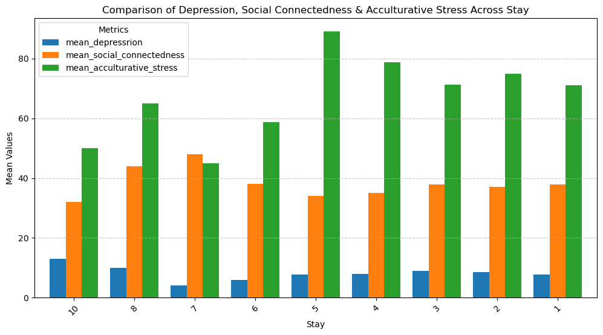

```python
# visualize the findings to understand better
import matplotlib.pyplot as plt

stay_analysis[['mean_depressrion', 'mean_social_connectedness', 'mean_acculturative_stress']].plot(
    kind='bar', figsize=(12,6), width=0.8
)

# Labels & Title
plt.xlabel('Stay')
plt.ylabel('Mean Values')
plt.title('Comparison of Depression, Social Connectedness & Acculturative Stress Across Stay')
plt.legend(title='Metrics')
plt.xticks(rotation=45)
plt.grid(axis='y', linestyle='--', alpha=0.7)
```

## By analyzing further, we can answer many questions. We can study mental health by gender, age, region and much more, we can also visualize the data